# Swire Coca Cola Modeling XGBoost

## Set up

```r
# Load necessary libraries
library(tidyverse)
library(readr)
library(readxl)
library(skimr)
library(janitor)
library(dplyr)
library(corrr)
```

```r
library(ggcorrplot)
library(car)
```

# MODELING: GXBOOST

```r
library(xgboost)
library(dplyr)
library(caret)
# Load dataset once
merged_data_xgb <- readRDS("merged_data_xgb.rds")
```

```r
# Select only numeric columns
numeric_cols <- merged_data_xgb %>%
  select(where(is.numeric))

# Convert to matrix format (for modeling)
feature_matrix <- as.matrix(numeric_cols %>% select(-c(delivered_cases, delivered_gallons)))

# Ensure no Inf or NaN values
feature_matrix[is.na(feature_matrix)] <- 0
feature_matrix[is.infinite(feature_matrix)] <- 0
```

```r
# Select only numeric columns
numeric_cols <- merged_data_xgb %>%
  select(where(is.numeric))

# Convert to matrix format (for modeling)
feature_matrix[is.infinite(feature_matrix)] <- 0  # Replace Inf values with 0

# Define target variables
target_cases <- numeric_cols$delivered_cases
target_gallons <- numeric_cols$delivered_gallons
```

```r
# Train-test split (Run once, reuse for both targets)
set.seed(123)
train_index <- createDataPartition(target_cases, p = 0.8, list = FALSE)
train_data <- feature_matrix[train_index, ]
test_data <- feature_matrix[-train_index, ]

# Create DMatrix (Used for both targets)
dtrain_data <- xgb.DMatrix(data = train_data)
dtest_data <- xgb.DMatrix(data = test_data)
```

**Step 2: Define a Function to Train XGBoost for Any Target**

```r
train_xgboost <- function(target_values, target_name) {

  # Define training labels
  train_label <- target_values[train_index]
  test_label <- target_values[-train_index]

  # Convert to DMatrix (add labels)
  dtrain <- xgb.DMatrix(data = train_data, label = train_label)
  dtest <- xgb.DMatrix(data = test_data, label = test_label)

  # Define XGBoost Parameters
  params <- list(
    booster = "gbtree",
    objective = "reg:squarederror",
    eval_metric = "rmse",
    eta = 0.1,
    max_depth = 6,
    subsample = 0.8,
    colsample_bytree = 0.8
  )

  # Train XGBoost
  xgb_model <- xgb.train(
    params = params,
    data = dtrain,
    nrounds = 100,
    watchlist = list(train = dtrain, test = dtest),
    early_stopping_rounds = 10,
    verbose = 1
  )

  # ✅ Save Model Correctly
  saveRDS(xgb_model, paste0("xgb_model_", target_name, ".rds"))

  # Get predictions
  preds <- predict(xgb_model, dtest)

  # Compute RMSE
  rmse <- sqrt(mean((preds - test_label)^2))
  print(paste("Final RMSE for", target_name, ":", round(rmse, 2)))

  # Return trained model & RMSE
  return(list(model = xgb_model, rmse = rmse))
}
```

**Step 3: Train Models for Both Targets**

```r
# Train XGBoost for Delivered Cases
model_cases <- train_xgboost(target_cases, "delivered_cases")
```

```
## Multiple eval metrics are present. Will use test_rmse for early stopping.
## Will train until test_rmse hasn't improved in 10 rounds.
##
## [1] "Final RMSE for delivered_cases : 17.11"
```

```r
# Train XGBoost for Delivered Gallons
model_gallons <- train_xgboost(target_gallons, "delivered_gallons")
```

```
## Multiple eval metrics are present. Will use test_rmse for early stopping.
## Will train until test_rmse hasn't improved in 10 rounds.
##
## [1] "Final RMSE for delivered_gallons : 26.01"
```

**Interpretation** **Delivered Cases RMSE: 17.11**

- The model’s predicted number of delivered cases deviates by ~17 cases on average from the actual values.
- A lower RMSE means the model is now making more precise predictions for delivered cases.

**Delivered Gallons RMSE: 26.01**

- The model’s predicted number of delivered gallons deviates by ~26 gallons on average from actual values.

Delivered cases are now more predictable, making this model a stronger tool for forecasting deliveries.

**Step 4: Compare Feature Importance for Both Models**

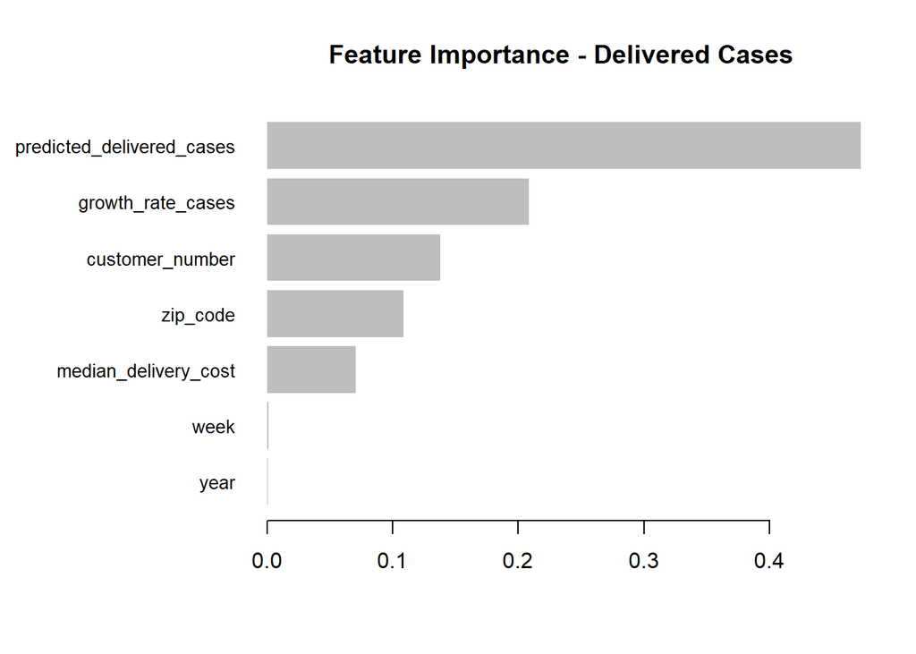

```r
# Feature importance for Delivered Cases
importance_cases <- xgb.importance(feature_names = colnames(feature_matrix), model = model_cases$model)
xgb.plot.importance(importance_cases, main = "Feature Importance - Delivered Cases")
```

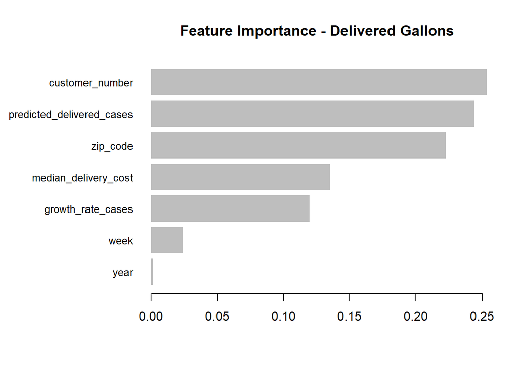

```r
# Feature importance for Delivered Gallons
importance_gallons <- xgb.importance(feature_names = colnames(feature_matrix), model = model_gallons$model)
xgb.plot.importance(importance_gallons, main = "Feature Importance - Delivered Gallons")
```

**Feature Importance**

**For delivered gallons, the most important features are:**

- Customer Number (most important)
- Predicted delivered cases (based on the model)
- Zip Code
- Median Delivery Cost
- Growth rate cases
- Week and Year (less important)

**For delivered cases, the most important features are:** - Predicted delivered cases (based on the model) (most important) - Growth rate cases - Customer number - Zip code - Median Delivery Cost

- Week and Year (less important)

## Improve Model

We’ll segment customers based on their order behavior using percentile-based segmentation.

### Step 1: Create Customer Segments

```r
# Step 1: Create Customer Segments based on delivered_gallons
# We’ll segment customers based on their order behavior using percentile-based segmentation.
merged_data_xgb <- merged_data_xgb %>%
  mutate(customer_segment = case_when(
    delivered_gallons >= quantile(delivered_gallons, 0.75, na.rm = TRUE) ~ "High-Volume",
    delivered_gallons > quantile(delivered_gallons, 0.25, na.rm = TRUE) ~ "Medium-Volume",
    TRUE ~ "Low-Volume"
  ))

# Ensure customer_segment exists before moving to Step 2
if (!"customer_segment" %in% colnames(merged_data_xgb)) {
  stop("Error: customer_segment column is still missing! Check Step 1.")
}
```

### Step 2: Convert Customer Segment to Categorical for XGBoost

```r
# Ensure customer_segment exists and is not empty
if (!"customer_segment" %in% colnames(merged_data_xgb)) stop("Error: customer_segment column not found!")
if (sum(is.na(merged_data_xgb$customer_segment)) > 0) stop("Error: customer_segment column is empty!")

# Convert customer_segment to factor
merged_data_xgb$customer_segment <- as.factor(merged_data_xgb$customer_segment)

# One-hot encode categorical variable (excluding intercept)
dummies <- model.matrix(~ customer_segment - 1, data = merged_data_xgb)

# Remove pre-existing customer_segment column and add the one-hot encoded columns back
merged_data_xgb <- merged_data_xgb %>%
  select(-customer_segment) %>%
  bind_cols(dummies)

# Verify dataset structure
print(dim(merged_data_xgb))
```

```
## [1] 13907517       24
```

```r
print(colnames(merged_data_xgb))
```

```
##  [1] "transaction_date"              "week"
##  [3] "year"                          "customer_number"
##  [5] "order_type"                    "delivered_cases"
##  [7] "delivered_gallons"             "primary_group_number"
##  [9] "frequent_order_type"           "first_delivery_date"
## [11] "on_boarding_date"              "cold_drink_channel"
## [13] "trade_channel"                 "sub_trade_channel"
## [15] "local_market_partner"          "co2_customer"
## [17] "zip_code"                      "median_delivery_cost"
## [19] "predicted_delivered_cases"     "growth_rate_cases"
## [21] "customer_decision"             "customer_segmentHigh-Volume"
## [23] "customer_segmentLow-Volume"    "customer_segmentMedium-Volume"
```

### Step 3: Re-run XGBoost with the New Feature (Customer Segments) FOR DELIVERED CASES

```r
# Now, we can train our XGBoost model again, this time with the customer segments included.

# Step 3: Prepare Data for XGBoost
# Convert all categorical variables to factors
merged_data_xgb <- merged_data_xgb %>%
  mutate(across(where(is.character), as.factor)) %>%
  mutate(across(where(is.factor), as.numeric))  # Convert factors to numeric

# Add customer segments based on delivered cases
merged_data_xgb <- merged_data_xgb %>%
  mutate(customer_segment = case_when(
    delivered_cases >= quantile(delivered_cases, 0.75, na.rm = TRUE) ~ "High-Volume",
    delivered_cases > quantile(delivered_cases, 0.25, na.rm = TRUE) ~ "Medium-Volume",
    TRUE ~ "Low-Volume"
  ))

# Convert the customer_segment to numeric for XGBoost compatibility
merged_data_xgb$customer_segment <- as.factor(merged_data_xgb$customer_segment)
merged_data_xgb$customer_segment <- as.numeric(merged_data_xgb$customer_segment)
```

```r
# Split the data into training and test sets
train_test_split <- createDataPartition(merged_data_xgb$delivered_cases, p = 0.8, list = FALSE)
train_data <- merged_data_xgb[train_test_split, ]
test_data <- merged_data_xgb[-train_test_split, ]

# Prepare the feature matrix (excluding target variable 'delivered_cases')
train_matrix <- as.matrix(train_data %>% select(-delivered_cases))
test_matrix <- as.matrix(test_data %>% select(-delivered_cases))

# Check for Inf and NaN values in the matrix and replace them
train_matrix[is.infinite(train_matrix) | is.na(train_matrix)] <- 0
test_matrix[is.infinite(test_matrix) | is.na(test_matrix)] <- 0

# Create the DMatrix for XGBoost
dtrain <- xgb.DMatrix(data = train_matrix, label = train_data$delivered_cases)
dtest <- xgb.DMatrix(data = test_matrix, label = test_data$delivered_cases)

# Define the parameters for the XGBoost model
params <- list(
  booster = "gbtree",
  objective = "reg:squarederror",  # Regression task
  eval_metric = "rmse",  # Root Mean Squared Error
  eta = 0.1,  # Learning rate
  max_depth = 6,  # Tree depth
  subsample = 0.8,  # Subsampling for boosting
  colsample_bytree = 0.8  # Feature sampling
)

# Train the XGBoost model
xgb_model <- xgb.train(
  params = params,
  data = dtrain,
  nrounds = 100,
  watchlist = list(train = dtrain, test = dtest),
  early_stopping_rounds = 10,
  verbose = 1
)
```

```
## Multiple eval metrics are present. Will use test_rmse for early stopping.
## Will train until test_rmse hasn't improved in 10 rounds.
##
```

```r
# Evaluate the model performance
preds <- predict(xgb_model, dtest)
rmse <- sqrt(mean((preds - test_data$delivered_cases)^2))
print(paste("Final RMSE for delivered_cases with segmentation:", round(rmse, 2)))
```

```
## [1] "Final RMSE for delivered_cases with segmentation: 11.51"
```

After segmentation it dropped from 17.11 to 11.51, which is great!

This result show that segmenting customers significantly improved prediction accuracy. We will just keep with delivered_cases since it has the lowest RMSE.

**Conclusion:** Segmenting customers based on delivered cases helped the model make better predictions.

### Exploring other segmentation

#### Segmentation for Delivered Gallons

```r
# Define segments based on percentile-based segmentation
merged_data_xgb <- merged_data_xgb %>%
  mutate(customer_segment = case_when(
    delivered_gallons >= quantile(delivered_gallons, 0.75, na.rm = TRUE) ~ "High-Volume",
    delivered_gallons > quantile(delivered_gallons, 0.25, na.rm = TRUE) ~ "Medium-Volume",
    TRUE ~ "Low-Volume"
  ))

# Check segmentation
table(merged_data_xgb$customer_segment)
```

```
##
##   High-Volume    Low-Volume Medium-Volume
##       3937599       7605341       2364577
```

**Delivered Gallons Segmentation:**

- High-Volume: 3,937,599
- Low-Volume: 7,605,341
- Medium-Volume: 2,364,577

The majority of customers fall into the Low-Volume category, which may suggest that most customers have a relatively low number of delivered gallons.

#### Segmentation for Delivered Cases

```r
### Step 1: Create Customer Segments for delivered_cases (Just for comparison)
merged_data_xgb <- merged_data_xgb %>%
  mutate(customer_segment_cases = case_when(
    delivered_cases >= quantile(delivered_cases, 0.75, na.rm = TRUE) ~ "High-Volume",
    delivered_cases > quantile(delivered_cases, 0.25, na.rm = TRUE) ~ "Medium-Volume",
    TRUE ~ "Low-Volume"
  ))

# Check segmentation for delivered_cases
table(merged_data_xgb$customer_segment_cases)
```

```
##
##   High-Volume    Low-Volume Medium-Volume
##       3521701       3708540       6677276
```

**Delivered Cases Segmentation:**